# Bayesian Logistic Regression Analysis of Heart Disease

Group Member:

- Samuel Christopher ~ 2802545466
- Michael Yeremia ~ 2802504876
- Nazhifa Kirana Mulia Nugraha ~ 2802545655
- Valentino Kurniawan ~ 2802524120

## 1. Introduction

This project applies Bayesian Logistic Regression to model a binary outcome variable using Bayesian inference. The objective is to estimate the posterior distribution of regression parameters, evaluate model performance using Bayesian model evaluation criteria, and interpret the results probabilistically.

The analysis is conducted using R with the JAGS engine for Markov Chain Monte Carlo (MCMC) sampling.

## 2. Model Specification

### 2.1 Likelihood Function

The likelihood is modeled using a Bernoulli distribution:

$$y_i \sim \text{Bernoulli}(\pi_i)$$

The success probability $\pi_i$ is linked to the predictors through the logistic (logit) function:

$$\text{logit}(\pi_i) = \log\left(\frac{\pi_i}{1-\pi_i}\right)
= \beta_0 + \beta_1 x_{1i} + \beta_2 x_{2i} + \beta_3 x_{3i}$$

### 2.2 Prior Distributions

Weakly informative normal priors are assigned to the regression coefficients:

$$\beta_0 \sim \mathcal{N}(0, 1)$$

$$\beta_1 \sim \mathcal{N}(0, 1)$$

$$\beta_2 \sim \mathcal{N}(0, 1)$$

$$\beta_3 \sim \mathcal{N}(0, 1)$$

These priors regularize the estimates while allowing sufficient flexibility.

### 2.3 Posterior Distribution

Using Bayes’ theorem, the posterior distribution of the parameters is given by:

$$p(\boldsymbol{\beta} \mid \mathbf{y}) \propto
p(\mathbf{y} \mid \boldsymbol{\beta}) \, p(\boldsymbol{\beta})$$

The likelihood function can be written as:

$$p(\mathbf{y} \mid \boldsymbol{\beta})
= \prod_{i=1}^{n} \pi_i^{y_i} (1-\pi_i)^{1-y_i}$$

Because the posterior distribution does not have a closed-form solution, inference is performed using Markov Chain Monte Carlo (MCMC) sampling.

## 3. Bayesian Estimation Using JAGS

Bayesian parameter estimation was performed using the JAGS (Just Another Gibbs Sampler) engine through Markov Chain Monte Carlo (MCMC) simulation. Two parallel chains were run to assess convergence. Running multiple MCMC chains from different initial values allows for more reliable assessment of convergence. If all chains converge to the same posterior distribution, this provides stronger evidence that the sampler has adequately explored the parameter space. An initial burn-in period of 1,000 iterations was used to allow the chains to reach the stationary distribution, followed by 2,000 iterations for posterior inference.

```r
library(rjags)
library(coda)
library(caret)

heart <- read.csv("heart.csv")

y <- heart$target

x1 <- as.numeric(scale(heart$age))
x2 <- as.numeric(scale(heart$chol))
x3 <- as.numeric(scale(heart$thalach))

n <- length(y)

data <- list(
  y = y,
  x1 = x1,
  x2 = x2,
  x3 = x3,
  n = n
)

model_string <- "model{
  for(i in 1:n){
    y[i] ~ dbern(pi[i])
    logit(pi[i]) <- beta0 + beta1*x1[i] + beta2*x2[i] + beta3*x3[i]
    like[i] <- dbin(y[i], pi[i], 1)
  }
  beta0 ~ dnorm(0,1)
  beta1 ~ dnorm(0,1)
  beta2 ~ dnorm(0,1)
  beta3 ~ dnorm(0,1)
}"

model_jags <- jags.model(
  textConnection(model_string),
  data = data,
  n.chains = 2
)
update(model_jags, 1000)

samples <- coda.samples(
  model_jags,
  variable.names = c("beta0","beta1","beta2","beta3"),
  n.iter = 2000
)
```

## 4. Model Diagnostics

### 4.1 Trace Plots

Trace plots display sampled parameter values across iterations and are used to evaluate convergence and mixing of the MCMC chains. Well-mixed traces that fluctuate around a stable mean without visible trends indicate that the chains have converged to the target posterior distribution.

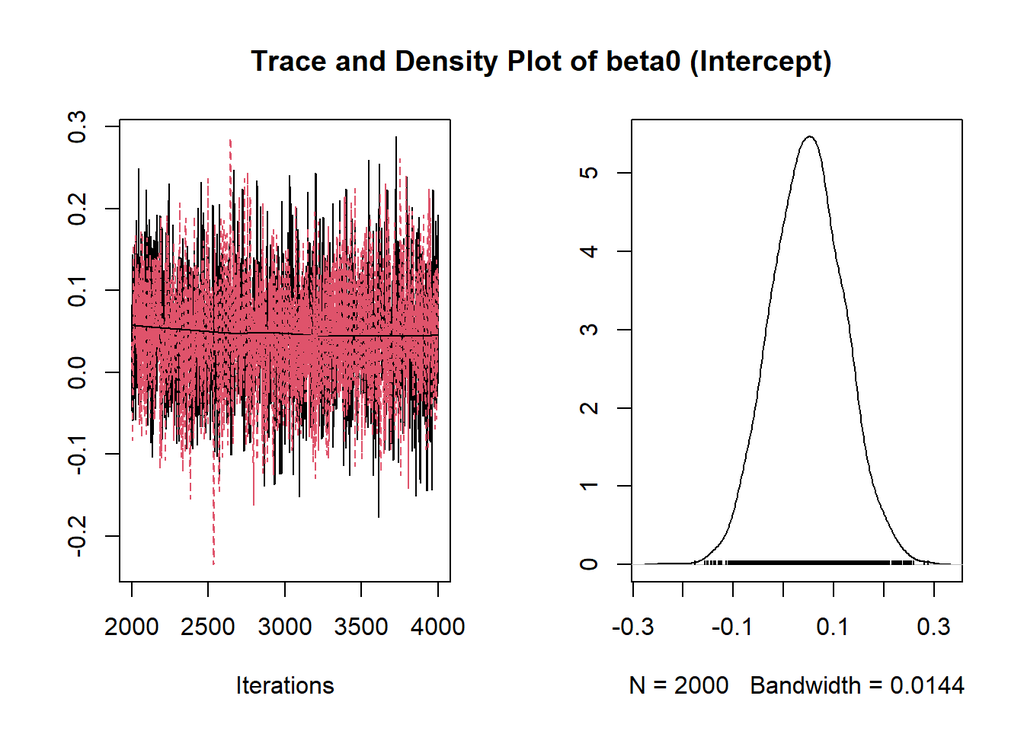

```r
plot(samples[, "beta0"])
title("Trace and Density Plot of beta0 (Intercept)")
```

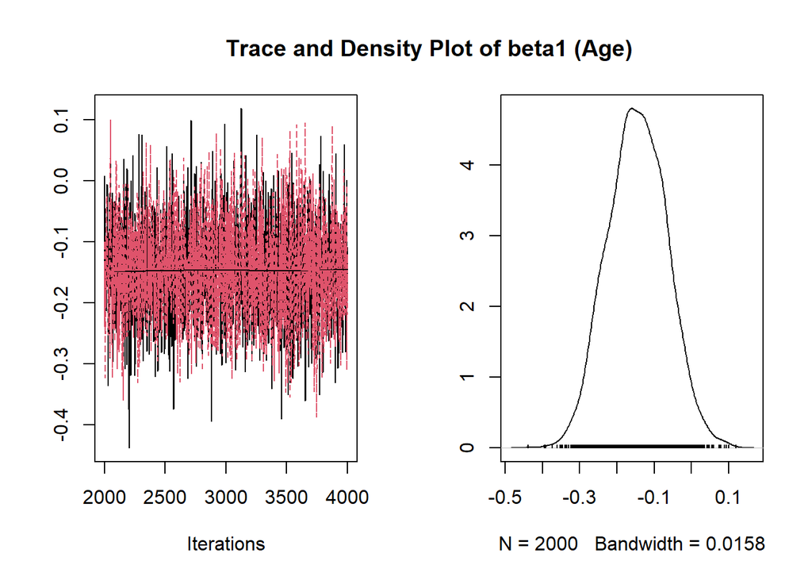

```r
plot(samples[, "beta1"])
title("Trace and Density Plot of beta1 (Age)")
```

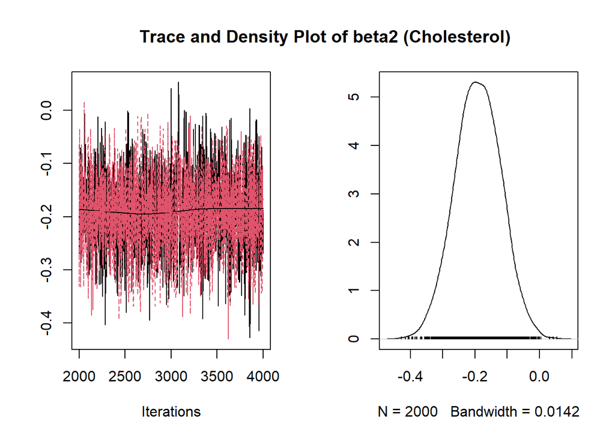

```r
plot(samples[, "beta2"])
title("Trace and Density Plot of beta2 (Cholesterol)")
```

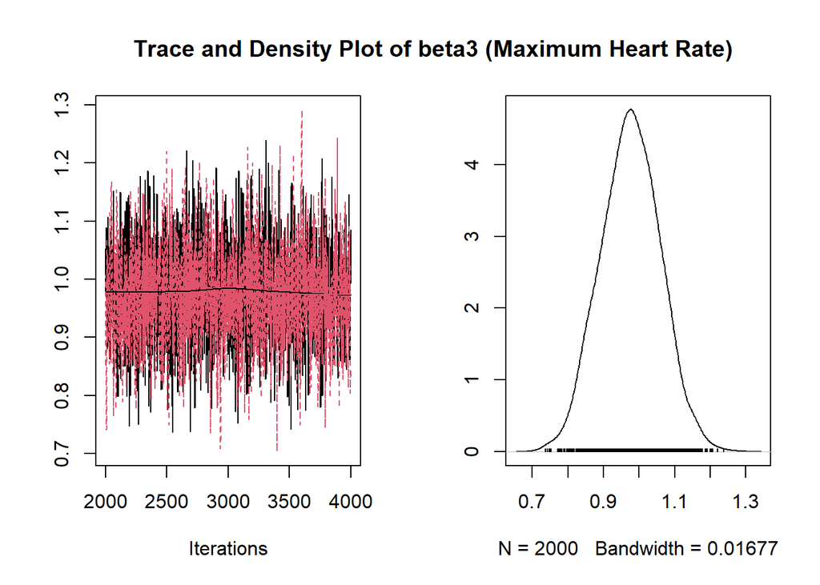

```r
plot(samples[, "beta3"])
title("Trace and Density Plot of beta3 (Maximum Heart Rate)")
```

### 4.2 Convergence Diagnostics

- Geweke Diagnostic

```r
geweke.diag(samples)
```

```
## [[1]]
##
## Fraction in 1st window = 0.1
## Fraction in 2nd window = 0.5
##
##   beta0   beta1   beta2   beta3
##  3.1839  0.2261 -0.1675  0.2745
##
##
## [[2]]
##
## Fraction in 1st window = 0.1
## Fraction in 2nd window = 0.5
##
##   beta0   beta1   beta2   beta3
## -0.4987 -0.2885  0.0340 -1.8972
```

The Geweke diagnostic compares the means of the early and late segments of each chain; values within ±1.96 indicate convergence.

- Gelman–Rubin Statistic (R-hat)

```r
gelman.diag(samples)
```

```
## Potential scale reduction factors:
##
##       Point est. Upper C.I.
## beta0          1       1.00
## beta1          1       1.00
## beta2          1       1.00
## beta3          1       1.01
##
## Multivariate psrf
##
## 1
```

The Gelman–Rubin statistic (R-hat) compares between-chain and within-chain variability, with values close to 1 indicating convergence.

- Effective Sample Size (ESS)

```r
effectiveSize(samples)
```

```
##    beta0    beta1    beta2    beta3
## 2361.230 1978.754 2358.166 2197.054
```

Effective Sample Size (ESS) measures the amount of independent information contained in the MCMC samples, where larger values indicate more reliable estimates.

## 5. Model Evaluation

Model evaluation was performed using Bayesian model fit criteria and predictive assessment techniques. Information criteria were used to assess out-of-sample predictive performance, while posterior predictive checks were used to evaluate model adequacy.

### 5.1 Deviance Information Criterion (DIC)

```r
dic.samples(model_jags, n.iter=2000)
```

```
## Mean deviance:  1210
## penalty 3.882
## Penalized deviance: 1214
```

The Deviance Information Criterion (DIC) is a Bayesian model comparison metric that balances model fit and complexity. Lower DIC values indicate a better trade-off between goodness of fit and model complexity.

### 5.2 Watanabe–Akaike Information Criterion (WAIC)

```r
samples_like <- coda.samples(model_jags, "like", n.iter=2000)
likelihood <- do.call(rbind, samples_like)
fbar <- colMeans(likelihood)
Pw <- sum(apply(log(likelihood), 2, var))
WAIC <- -2 * sum(log(fbar)) + 2 * Pw
WAIC
```

```
## [1] 1213.979
```

In the WAIC computation, the term f̄ represents the average likelihood across posterior samples, while Pw corresponds to the effective number of parameters and acts as a penalty for model complexity. WAIC balances goodness of fit and model flexibility, with lower values indicating better expected predictive performance.

### 5.3 Posterior Predictive Check (PPC)

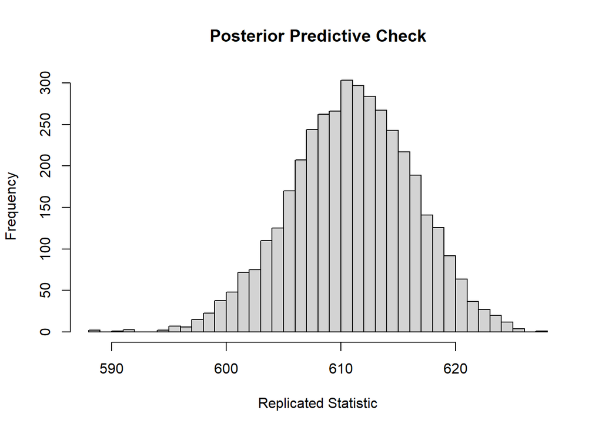

```r
likelihood <- as.matrix(samples_like)

ppc_stat <- rowSums(likelihood)
obs_stat <- sum(y)

hist(ppc_stat,
     breaks = 30,
     main = "Posterior Predictive Check",
     xlab = "Replicated Statistic")

abline(v = obs_stat, lwd = 2, lty = 2)
```

Posterior predictive checks assess whether the model is capable of reproducing key features of the observed data. Replicated datasets are generated from the posterior distribution and compared to the observed statistic. When the observed statistic falls within the distribution of replicated values, the model is considered to provide an adequate fit.

## 6. Posterior Inference

Posterior inference focuses on summarizing and interpreting the estimated posterior distributions of the regression coefficients, including measures of central tendency and uncertainty.

```r
summary(samples)
```

```
##
## Iterations = 2001:4000
## Thinning interval = 1
## Number of chains = 2
## Sample size per chain = 2000
##
## 1. Empirical mean and standard deviation for each variable,
##    plus standard error of the mean:
##
##           Mean      SD Naive SE Time-series SE
## beta0  0.04764 0.07135 0.001128       0.001472
## beta1 -0.14511 0.07828 0.001238       0.001760
## beta2 -0.19056 0.07035 0.001112       0.001449
## beta3  0.97605 0.08308 0.001314       0.001779
##
## 2. Quantiles for each variable:
##
##           2.5%       25%     50%      75%     97.5%
## beta0 -0.08857 -0.001752  0.0476  0.09583  0.190946
## beta1 -0.29378 -0.199369 -0.1451 -0.08944  0.008357
## beta2 -0.32928 -0.237923 -0.1901 -0.14111 -0.054291
## beta3  0.81588  0.919266  0.9767  1.03293  1.140650
```

Posterior summaries include posterior means and 95% credible intervals. A credible interval represents the range within which the parameter lies with 95% posterior probability, given the observed data and prior assumptions.

### 6.1 Credible Intervals

The forest plot visualizes posterior means and 95% credible intervals for each regression coefficient. The vertical dashed line at zero represents no effect. Predictors whose credible intervals do not cross zero exhibit stronger posterior evidence of association with heart disease risk.

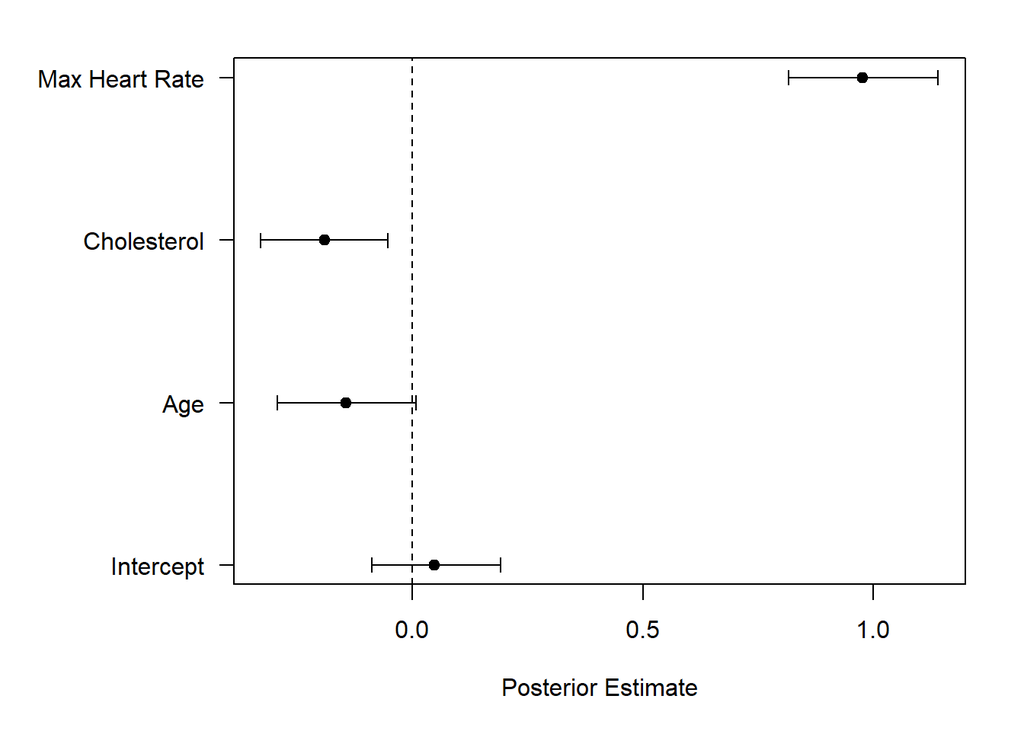

```r
post <- as.matrix(samples)

post_summary <- cbind(
  mean  = colMeans(post),
  lower = apply(post, 2, quantile, 0.025),
  upper = apply(post, 2, quantile, 0.975)
)

post_summary <- post_summary[c("beta0","beta1","beta2","beta3"), ]

par(mar = c(5,8,2,2))

plot(post_summary[, "mean"],
     1:4,
     xlim = range(post_summary[, c("lower","upper")]),
     yaxt = "n",
     xlab = "Posterior Estimate",
     ylab = "",
     pch = 19)

arrows(post_summary[, "lower"], 1:4,
       post_summary[, "upper"], 1:4,
       angle = 90, code = 3, length = 0.05)

abline(v = 0, lty = 2)

axis(2, at = 1:4,
     labels = c("Intercept", "Age", "Cholesterol", "Max Heart Rate"),
     las = 1)
```

### 6.2 Posterior Interpretation

Each regression coefficient is interpreted probabilistically. A coefficient whose 95% credible interval does not include zero is considered to have strong evidence of association with the response variable.

## 7. Prediction Performance

```r
XX <- cbind(1, x1, x2, x3)

beta_hat <- summary(samples)$statistics[,1]

pred_prob <- 1 / (1 + exp(-XX %*% beta_hat))
pred <- ifelse(pred_prob > 0.5, 1, 0)

confusionMatrix(factor(pred), factor(y))
```

```
## Confusion Matrix and Statistics
##
##           Reference
## Prediction   0   1
##          0 325 147
##          1 174 379
##
##                Accuracy : 0.6868
##                  95% CI : (0.6574, 0.7151)
##     No Information Rate : 0.5132
##     P-Value [Acc > NIR] : <2e-16
##
##                   Kappa : 0.3724
##
##  Mcnemar's Test P-Value : 0.1467
##
##             Sensitivity : 0.6513
##             Specificity : 0.7205
##          Pos Pred Value : 0.6886
##          Neg Pred Value : 0.6854
##              Prevalence : 0.4868
##          Detection Rate : 0.3171
##    Detection Prevalence : 0.4605
##       Balanced Accuracy : 0.6859
##
##        'Positive' Class : 0
##
```

The model achieved an overall classification accuracy of approximately 69%. This moderate predictive performance is reasonable given the limited number of predictors and the complex nature of heart disease outcomes. The primary objective of the analysis is probabilistic inference and uncertainty quantification rather than maximizing predictive accuracy.